# Student Score-Hours

Ameen Abdulbaru

2023-09-03

[figure not shown]

## Spark Foundation Internship Our Vision Statement A world of enabled and connected little minds, building future. Our Mission Statement. To inspire students, help them innovate and let them integrate to build the next generation humankind. Inspire: To inspire, motivate and encourage students to learn, create and help build a better society. Innovate: To teach new ways of thinking, to innovate and solve the problems on their own. Integrate: To let the students integrate, and help each other, learn from each other and do well together.

### 1. PREDICTION USING SUPERVISED ML

**Student scores by Hours spent**

The dataset consist of student scores along with the hours spent in studying for a particular subject.

**Study Task** The dataset study task is to predict the percentage of student based on the amount of hours spent and also to predict the scores of student that spent 9.25 hours.

**Packages used for analysis**

**Analysis**

```
## Rows: 25
## Columns: 2
## $ Hours  <dbl> 2.5, 5.1, 3.2, 8.5, 3.5, 1.5, 9.2, 5.5, 8.3, 2.7, 7.7, 5.9, 4.5…
## $ Scores <int> 21, 47, 27, 75, 30, 20, 88, 60, 81, 25, 85, 62, 41, 42, 17, 95,…
```

```
##   Hours Scores
## 1   2.5     21
## 2   5.1     47
## 3   3.2     27
## 4   8.5     75
## 5   3.5     30
## 6   1.5     20
```

```
##      Hours           Scores
##  Min.   :1.100   Min.   :17.00
##  1st Qu.:2.700   1st Qu.:30.00
##  Median :4.800   Median :47.00
##  Mean   :5.012   Mean   :51.48
##  3rd Qu.:7.400   3rd Qu.:75.00
##  Max.   :9.200   Max.   :95.00
```

-The glimpse packages shows a little peek about the data set in other to understand what the datset is about. -The head package tend to indicate a part of the data set while showing the necessary columns of the data set as well as its information. -The summary data set show the statistical evaluation of the data set.

**statistic Analysis**

```
## [1] 0.9761907
```

The analysis above is a simple indication of what relationship exist between both variables in this case(Student scores~Hours spent)

```
##
## Call:
## lm(formula = Hours ~ Scores, data = scores)
##
## Residuals:
##     Min      1Q  Median      3Q     Max
## -0.7879 -0.4433 -0.2181  0.5096  1.1953
##
## Coefficients:
##              Estimate Std. Error t value Pr(>|t|)
## (Intercept) -0.006286   0.258038  -0.024    0.981
## Scores       0.097480   0.004517  21.583   <2e-16 ***
## ---
## Signif. codes:  0 '***' 0.001 '**' 0.01 '*' 0.05 '.' 0.1 ' ' 1
##
## Residual standard error: 0.5595 on 23 degrees of freedom
## Multiple R-squared:  0.9529, Adjusted R-squared:  0.9509
## F-statistic: 465.8 on 1 and 23 DF,  p-value: < 2.2e-16
```

The analysis indicates a more radical approach of showing a more detailed linear regression of both variables. Using “lm” function to carry out regression or analysis of covariance of the variables.

**Visualising the data correlation**

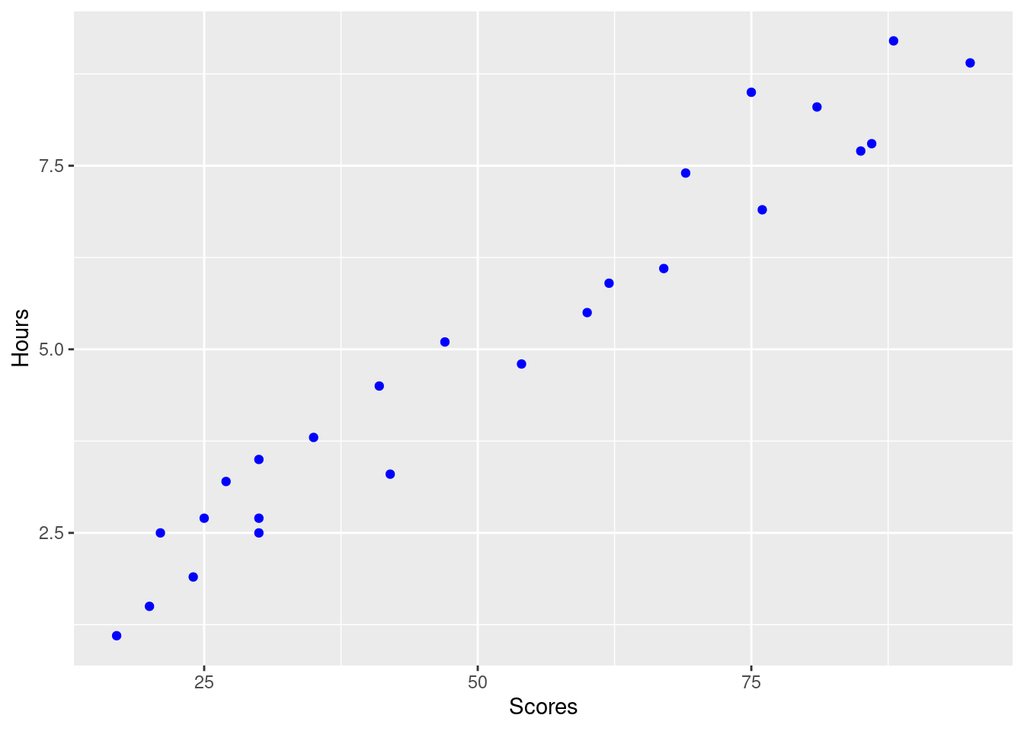